# Models for Polytomous Categorical Outcomes

## Predicting more than two categories

Sociology 513, Models for Polytomous Categorical Outcomes: Introduction

- It is possible to extend the basic logistic regression model predicting a dichotomous outcome to a categorical outcome with more than two categories (polytomous).
- The complexity of the model increases rapidly with the number of categories.
- In the polytomous case, we can distinguish different kinds of models for nominal and ordinal variables. Models for nominal variables can be used on ordinal variables (essentially ignoring their order), but not vice versa.

## Models for Nominal Outcomes

Models for Polytomous Categorical Outcomes

## New dataset example

Sociology 513, Models for Polytomous Categorical Outcomes: Models for Nominal Outcomes

- American Community Survey data on race reporting based on ancestry responses.
- Ancestry is a write-in response with two separate lines.
- We are using the subset of data that includes all individuals who gave two ancestry responses that suggest both a white and black ancestry (e.g. “African American” and “Irish”).
- We will consider three race responses for these individuals: white, black, or white and black.
- How does the decision to identify racially vary by socioeconomic and demographic characteristics?

## two-way table of race reporting by college

Sociology 513, Models for Polytomous Categorical Outcomes: Models for Nominal Outcomes

```r
tab <- table(wbreport$racereport, wbreport$college)
tab
```

```
##
##                  No   Yes
##   White/Black 32899  2781
##   Black       23374  3993
##   White       12112  1598
```

```r
prop.table(tab, 2)
```

```
##
##                      No       Yes
##   White/Black 0.4810850 0.3321787
##   Black       0.3418001 0.4769470
##   White       0.1771149 0.1908743
```

College-educated respondents are much less likely to report as white and black and substantially more likely to report as black, and slightly more likely to report as white.

## Odds Ratios by College Completion

Sociology 513, Models for Polytomous Categorical Outcomes: Models for Nominal Outcomes

```
##
##                 Yes    No
##   Black        3993 23374
##   White        1598 12112
##   White/Black  2781 32899
```

\[\frac{3993*32899}{2781*23374}=2.02\]

The odds of identifying as black rather than white and black are twice as high among college-educated individuals than among those without a college degree.

\[\frac{1598*32899}{2781*12112}=1.56\] The odds of identifying as white rather than white and black are 56% higher among college-educated individuals than among those without a college degree.

## Two logistic regression models

Sociology 513, Models for Polytomous Categorical Outcomes: Models for Nominal Outcomes

- Limit data to individuals who identified as black or white/black and run a logistic regression model on black identification.
- Limit data to individuals who identified as white or white/black and run a logistic regression model on white identification.

```r
model.black <- glm((racereport=="Black")~college, data=subset(wbreport, racereport!="White"),
                   family=binomial)
model.white <- glm((racereport=="White")~college, data=subset(wbreport, racereport!="Black"),
                   family=binomial)
rbind("black vs Multi"=coef(model.black),"white vs Multi"=coef(model.white))
```

```
##                (Intercept) collegeYes
## black vs Multi  -0.3418180  0.7035502
## white vs Multi  -0.9992456  0.4451878
```

- The odds ratio of black vs. white/black identification is 2.02 (\(e^{0.70355}\)).
- The odds ratio of white vs. white/black identification is 1.56 (\(e^{0.44519}\)).
- The intercepts give the baseline odds of black and white identification vs. white/black identification, respectively, among the non-college educated.

## The Multinomial Logit Model

Sociology 513, Models for Polytomous Categorical Outcomes: Models for Nominal Outcomes

- The multinomial logit model accomplishes the same result as these two separate logistic regression model, but estimates parameters using a single MLE procedure. This allows for a single measure of model log-likelihood and deviance.
- One of the categories of the dependent variable must serve as the reference category. In the example we are using, the white and black category served as the reference. The choice of reference is arbitrary.
- For a model with \(J\) categories of the dependent variable, we will get \(J-1\) coefficients for each independent variable.
- Multinomial logit models can be estimated in R with the `multinom` function in the `nnet` library.

## Multinomial logit model example

Sociology 513, Models for Polytomous Categorical Outcomes: Models for Nominal Outcomes

```r
library(nnet)
model <- multinom(racereport~college, data=wbreport)
```

```r
summary(model)
```

```
## Call:
## multinom(formula = racereport ~ college, data = wbreport)
##
## Coefficients:
##       (Intercept) collegeYes
## Black  -0.3418185  0.7035608
## White  -0.9992481  0.4452018
##
## Std. Errors:
##       (Intercept) collegeYes
## Black  0.00855445 0.02613812
## White  0.01062821 0.03314097
##
## Residual Deviance: 157596.4
## AIC: 157604.4
```

## Formal multinomial model specification

Sociology 513, Models for Polytomous Categorical Outcomes: Models for Nominal Outcomes

\[\log(p_{ij}/p_{i1})=\beta_{0j}+\beta_{1j}x_{i1}+\beta_{2j}x_{i2}+\ldots+\beta_{pj}x_{ip}\]

- The model fits the log-odds of being in the \(j\)th outcome category relative to the reference outcome category as linear function of the independent variables.
- Each independent variable will have \(J-1\) coefficients rather than a single coefficient.
- Each \(\beta_j\) gives the log odds ratio of being in the \(j\)th outcome category rather than the reference outcome category for a one unit change in the given independent variable.
- The intercepts \(\beta_{0j}\) give the baseline odds of being in the \(j\)th outcome category rather than the reference outcome category when all the independent variables are zero.

## Changing the reference category

Sociology 513, Models for Polytomous Categorical Outcomes: Models for Nominal Outcomes

If we want to change the reference category for the dependent variable, we can recalculate the regression coefficients as follows:

\[\beta_j-\beta_{j'}\]

Where \(j'\) is the new category that we want to set as the reference.

Lets try this out for our example, where we set the new reference to be identifying as black.

```r
coefs <- coef(model)
coefs.new <- rbind(c(0,0)-coefs[1,], coefs[2,]-coefs[1,])
rownames(coefs.new) <- c("White/Black", "White")
coefs.new
```

```
##             (Intercept) collegeYes
## White/Black   0.3418185 -0.7035608
## White        -0.6574295 -0.2583589
```

The white/black effects are just the inverse of the black effects.

## Changing the reference categories

Sociology 513, Models for Polytomous Categorical Outcomes: Models for Nominal Outcomes

```r
library(nnet)
model.blackref <- multinom(relevel(racereport, "Black")~college, data=wbreport)
```

```r
coef(model.blackref)
```

```
##             (Intercept) collegeYes
## White/Black   0.3418283 -0.7035537
## White        -0.6574070 -0.2583988
```

```r
coefs.new
```

```
##             (Intercept) collegeYes
## White/Black   0.3418185 -0.7035608
## White        -0.6574295 -0.2583589
```

## Estimating predicted probabilities

Sociology 513, Models for Polytomous Categorical Outcomes: Models for Nominal Outcomes

Because there are multiple categories to consider, its often helpful to try to predict how the distribution of the dependent variable will change across different values of the independent variable. For a given set of independent variables \(X\), the probability \(P_i\) of being in category \(i\) is:

\[P_i=\frac{exp(X\beta_i)}{\sum_Jexp(X\beta_j)}\]

The trick here is to remember that the reference category will always have \(X\beta\) of zero which exponentiates to one. Therefore, the denominator will always include a one in the sum.

## Estimating Predicted Probabilities Example

Sociology 513, Models for Polytomous Categorical Outcomes: Models for Nominal Outcomes

```r
temp <- rbind("White/Black"=c(0,0),coef(model))
temp
```

```
##             (Intercept) collegeYes
## White/Black   0.0000000  0.0000000
## Black        -0.3418185  0.7035608
## White        -0.9992481  0.4452018
```

```r
exp(temp[,1])/sum(exp(temp[,1]))
```

```
## White/Black       Black       White
##   0.4810853   0.3418001   0.1771145
```

```r
exp(temp[,1]+temp[,2])/sum(exp(temp[,1]+temp[,2]))
```

```
## White/Black       Black       White
##   0.3321764   0.4769484   0.1908752
```

## Using `predict` to estimate probabilities

Sociology 513, Models for Polytomous Categorical Outcomes: Models for Nominal Outcomes

You can also do this in R with the `predict` command where you feed in a new data set to get predicted values.

```r
predicted.probs <- predict(model, newdata = data.frame(college=c("No","Yes")), type="probs")
predicted.probs
```

```
##   White/Black     Black     White
## 1   0.4810853 0.3418001 0.1771145
## 2   0.3321764 0.4769484 0.1908752
```

```r
t(prop.table(tab, 2))
```

```
##
##       White/Black     Black     White
##   No    0.4810850 0.3418001 0.1771149
##   Yes   0.3321787 0.4769470 0.1908743
```

The results here are identical to the conditional distributions estimated by the two-way table.

## A full model

Sociology 513, Models for Polytomous Categorical Outcomes: Models for Nominal Outcomes

```r
model.full <- multinom(racereport~college+poor+agectr+agectrsq+foreign+female,
                       data=wbreport)
```

```r
round(coef(model.full),5)
```

```
##       (Intercept) collegeYes  poorYes  agectr agectrsq foreignYes   female
## Black    -0.13009   -0.25373  0.09973 0.04543   -1e-05    0.64213 -0.03511
## White    -0.70266   -0.60671 -0.18088 0.05360   -7e-05    0.03437 -0.00989
```

- The effects of college are very different with controls (particularly for age). College now seems more likely to push respondents away from both singl-race identifations towards multiracial identification.
- How do we interpret the effects of age on racial identification? Age is centered on 22 years and a square is included, so its not easy to sort it out just from the coefficient values.

## Estimating the effect of age

Sociology 513, Models for Polytomous Categorical Outcomes: Models for Nominal Outcomes

Lets get predicted probabilities for the effect of age from 22 to 75. We will estimate probabilities for the reference categories of the other variables (non-college, non-poor, male, native-born).

In order to do this, we need to create a fake dataset where all values are held at the reference except for age and its square, and then feed this into the `predict` function.

```r
x <- 22:75
fakedata <- data.frame(college=rep("No",length(x)), poor=rep("No",length(x)),
                                                foreign=rep("No",length(x)), female=rep(0,length(x)),
                                                agectr=x-22, agectrsq=(x-22)^2)
predicted.probs <- predict(model.full, fakedata, type="probs")
head(predicted.probs)
```

```
##   White/Black     Black     White
## 1   0.4213579 0.3699588 0.2086833
## 2   0.4096159 0.3763606 0.2140234
## 3   0.3979874 0.3826591 0.2193535
## 4   0.3864840 0.3888483 0.2246677
## 5   0.3751172 0.3949225 0.2299603
## 6   0.3638977 0.4008767 0.2352257
```

## Estimating the effect of age

Sociology 513, Models for Polytomous Categorical Outcomes: Models for Nominal Outcomes

The `matplot` function can be used to plot multiple lines from a matrix in one graph:

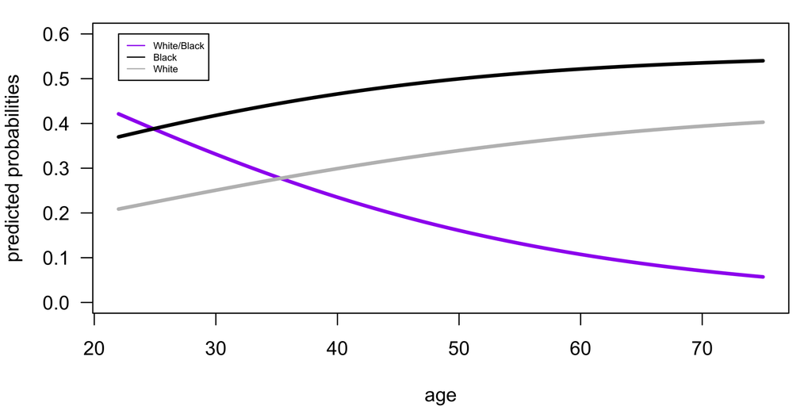

```r
par(mar=c(4,4,1,1))
matplot(x, predicted.probs, type="l", lwd=3, col=c("purple","black","grey"),
        lty=1, las=1, ylab="predicted probabilities", xlab="age", ylim=c(0,0.6))
legend(22, 0.6, legend=c("White/Black","Black","White"), lty=1, col=c("purple","black","grey"), cex=0.5)
```

## Effects of age and college completion

Sociology 513, Models for Polytomous Categorical Outcomes: Models for Nominal Outcomes

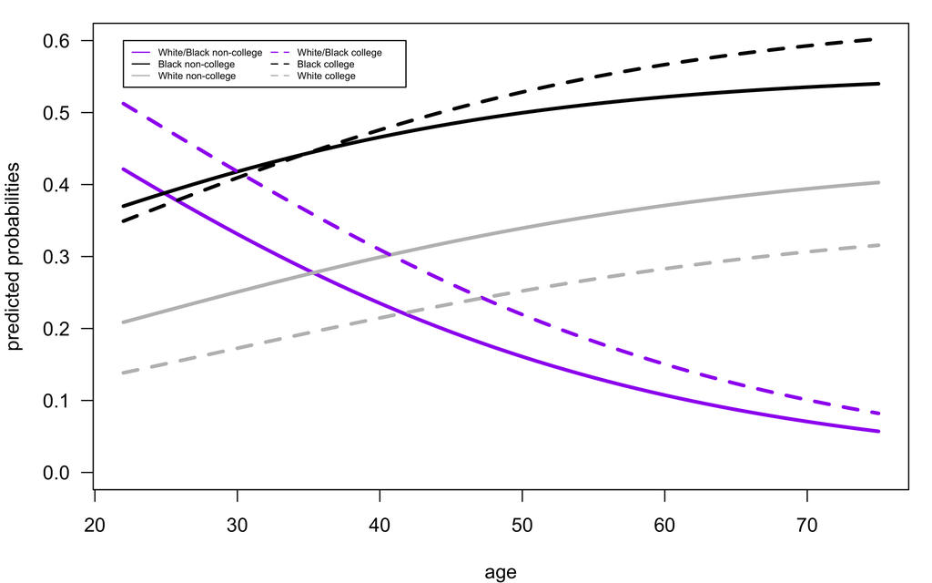

## Models for Ordinal Outcomes

Models for Polytomous Categorical Outcomes

## Example for ordinal outcomes

Sociology 513, Models for Polytomous Categorical Outcomes: Models for Ordinal Outcomes

Using the National Election Study data, lets look at attitudes toward gay marriage by whether a respondent completed a BA degree.

```r
politics$college <- as.numeric(politics$educ) > 3
tab <- table(politics$gaymarriage, politics$college)
tab
```

```
##
##                        FALSE TRUE
##   No legal recognition   575  198
##   Civil unions           623  369
##   Support gay marriage  1385 1088
```

```r
prop.table(tab, 2)
```

```
##
##                            FALSE      TRUE
##   No legal recognition 0.2226094 0.1196375
##   Civil unions         0.2411924 0.2229607
##   Support gay marriage 0.5361982 0.6574018
```

## Multinomial model

Sociology 513, Models for Polytomous Categorical Outcomes: Models for Ordinal Outcomes

We could just estimate this model as a multinomial model and ignore the ordinal nature of the dependent variable.

```r
model.multin <- multinom(gaymarriage~college, data=politics)
```

```r
round(coef(model.multin),3)
```

```
##                      (Intercept) collegeTRUE
## Civil unions               0.080       0.542
## Support gay marriage       0.879       0.825
```

## Estimating log-odds ratios by hand

Sociology 513, Models for Polytomous Categorical Outcomes: Models for Ordinal Outcomes

```
##
##                        FALSE TRUE
##   No legal recognition   575  198
##   Civil unions           623  369
##   Support gay marriage  1385 1088
```

## Adjacent Category Logit Model

Sociology 513, Models for Polytomous Categorical Outcomes: Models for Ordinal Outcomes

The Adjacent Category Logit (ACL) Model estimates the log-odds ratio of being in the higher category \(j\) for each pair of adjacent categories \(j\) and \(j-1\):

\[\log(p_{ij}/p_{i(j-1)})=\beta_{0j}+\beta_{1j}x_{i1}+\beta_{2j}x_{i2}+\dots+\beta_{pj}x_{ip}\]

- The ACL takes advantage of the ordinal structure of the dependent variable to get the odds ratio between each adjacent set of categories on the ordinal scale.
- In general, we can estimate the parameters for an adjacent category logit model from multinomial model results by coding the lowest category as the reference and taking: \[\beta_j-\beta_{j-1}\] for all coefficients.
- In terms of model fit, the ACL is identical to the multinomial model, it just gives a more intuitive interpretation for ordinal responses.
- The multinomial model is sometimes called the Baseline Category Logit (BCL) model to more clearly distinguish it from the ACL. Both are estimating the same basic model, but in the BCL the reference is fixed, while in the ACL, the reference changes for each comparison.

## Adjacent Category Logit Model Example

Sociology 513, Models for Polytomous Categorical Outcomes: Models for Ordinal Outcomes

```r
round(coef(model.multin),3)
```

```
##                      (Intercept) collegeTRUE
## Civil unions               0.080       0.542
## Support gay marriage       0.879       0.825
```

```r
model.acl <- diff(rbind(c(0,0),round(coef(model.multin),3)))
model.acl
```

```
##                      (Intercept) collegeTRUE
## Civil unions               0.080       0.542
## Support gay marriage       0.799       0.283
```

Sociology 513, Models for Polytomous Categorical Outcomes: Models for Ordinal Outcomes

```r
model.acl
```

```
##                      (Intercept) collegeTRUE
## Civil unions               0.080       0.542
## Support gay marriage       0.799       0.283
```

```r
coef(glm((gaymarriage=="Civil union")~college, family=binomial,
            data=subset(politics, gaymarriage!="Support gay marriage")))
```

```
##   (Intercept)   collegeTRUE
## -2.656607e+01 -5.666321e-14
```

```r
coef(glm((gaymarriage=="Support gay marriage")~college, family=binomial,
            data=subset(politics, gaymarriage!="No legal recognition")))
```

```
## (Intercept) collegeTRUE
##   0.7989089   0.2823909
```

## The Cumulative Probability

Sociology 513, Models for Polytomous Categorical Outcomes: Models for Ordinal Outcomes

Another way to think about differences in the distribution of an ordinal variable is by comparing the cumulative probability of being in a given category or higher.

```r
p <- prop.table(tab,2)
p
```

```
##
##                            FALSE      TRUE
##   No legal recognition 0.2226094 0.1196375
##   Civil unions         0.2411924 0.2229607
##   Support gay marriage 0.5361982 0.6574018
```

```r
cump <- apply(p[3:1,],2,cumsum)[3:1,]
cump
```

```
##
##                            FALSE      TRUE
##   No legal recognition 1.0000000 1.0000000
##   Civil unions         0.7773906 0.8803625
##   Support gay marriage 0.5361982 0.6574018
```

## The Cumulative Odds

Sociology 513, Models for Polytomous Categorical Outcomes: Models for Ordinal Outcomes

We can convert these cumulative probabilities into cumulative odds:

```r
cumodds <- cump/(1-cump)
cumodds
```

```
##
##                           FALSE     TRUE
##   No legal recognition      Inf      Inf
##   Civil unions         3.492174 7.358586
##   Support gay marriage 1.156093 1.918871
```

## Cumulative/Ordered Logit Model

Sociology 513, Models for Polytomous Categorical Outcomes: Models for Ordinal Outcomes

\[log(P(y_i>=j)/P(y_i<j))=\alpha_j+\beta_{1j}x_{i1}+\beta_{2j}x_{i2}+\dots+\beta_{pj}x_{ip}\]

- The dependent variable is the cumulative log odds of being in the \(j\)th category or higher.
- The regression coefficients tell us how the the cumulative log odds of being in the \(j\)th or higher category change due to a one unit increase in \(x\).
- The \(\alpha_j\) are the intercepts but they are often called the “cut points”. They define the cumulative distribution of ordinal responses when all the \(x\)’s are zero.
- Because this model allows the effect of each independent variable to be different at each cut-point, it has the same model fit as the multinomial model, but a different parameterization.

## Estimating the cumulative logit model

Sociology 513, Models for Polytomous Categorical Outcomes: Models for Ordinal Outcomes

```r
lcumodds <- log(cumodds[2:3,])
lcumodds
```

```
##
##                            FALSE      TRUE
##   Civil unions         1.2505244 1.9958678
##   Support gay marriage 0.1450466 0.6517371
```

```r
model.cumlogit <- data.frame(cut=lcumodds[,1],college=c(diff(t(lcumodds))))
model.cumlogit
```

```
##                            cut   college
## Civil unions         1.2505244 0.7453433
## Support gay marriage 0.1450466 0.5066905
```

## Interpreting terms in cumulative logit model

Sociology 513, Models for Polytomous Categorical Outcomes: Models for Ordinal Outcomes

```r
exp(model.cumlogit)
```

```
##                           cut  college
## Civil unions         3.492174 2.107165
## Support gay marriage 1.156093 1.659789
```

Sociology 513, Models for Polytomous Categorical Outcomes: Models for Ordinal Outcomes

```r
model.cumlogit
```

```
##                            cut   college
## Civil unions         1.2505244 0.7453433
## Support gay marriage 0.1450466 0.5066905
```

```r
coef(glm((gaymarriage=="Support gay marriage" | gaymarriage=="Civil union")~college,
         data=politics, family=binomial))
```

```
## (Intercept) collegeTRUE
##   0.1450466   0.5066905
```

```r
coef(glm((gaymarriage=="Support gay marriage")~college,
         data=politics, family=binomial))
```

```
## (Intercept) collegeTRUE
##   0.1450466   0.5066905
```

## Estimating models with vglm

Sociology 513, Models for Polytomous Categorical Outcomes: Models for Ordinal Outcomes

- The `VGAM` library includes a function called `vglm` for estimating “vector generalized linear models.” This package can be used to estimate a variety of nominal and ordinal response models.
- The structure of the dependent variable in `vglm` is somewhat different than `glm` or `lm`. We need to feed in a matrix of responses ordered from lowest to highest response category, where each vector is a sequence of zeroes/ones or FALSE/TRUE for being in that particular category.

```r
table(politics$gaymarriage)/sum(table(politics$gaymarriage))
```

```
##
## No legal recognition         Civil unions Support gay marriage
##            0.1823974            0.2340727            0.5835300
```

```r
politics$norecog <- politics$gaymarriage=="No legal recognition"
politics$civil <- politics$gaymarriage=="Civil unions"
politics$marriage <- politics$gaymarriage=="Support gay marriage"
apply(politics[,c("norecog","civil","marriage")],2,mean, na.rm=TRUE)
```

```
##   norecog     civil  marriage
## 0.1823974 0.2340727 0.5835300
```

## `vglm` models

Sociology 513, Models for Polytomous Categorical Outcomes: Models for Ordinal Outcomes

Multinomial model:

```r
model.multinom <- vglm(cbind(norecog, civil, marriage)~college,family=multinomial(refLevel=1),
                       data=politics)
```

Adjacent category logit model:

```r
model.acl <- vglm(cbind(norecog, civil, marriage)~college, family=acat(parallel=FALSE), data=politics)
```

Cumulative logit model:

```r
model.cumlogit <- vglm(cbind(norecog, civil, marriage)~college,
                       family=cumulative(parallel=FALSE,reverse=TRUE), data=politics)
```

Deviance is the same because they are the same model differently parameterized.

```r
sapply(list(model.multinom,model.acl,model.cumlogit),deviance)
```

```
## [1] 8087.233 8087.233 8087.233
```

## `vglm` models

Sociology 513, Models for Polytomous Categorical Outcomes: Models for Ordinal Outcomes

```r
coef(model.multinom)
```

```
## (Intercept):1 (Intercept):2 collegeTRUE:1 collegeTRUE:2
##    0.08017648    0.87908538    0.54235314    0.82474402
```

```r
coef(model.acl)
```

```
## (Intercept):1 (Intercept):2 collegeTRUE:1 collegeTRUE:2
##    0.08017648    0.79890890    0.54235314    0.28239088
```

```r
coef(model.cumlogit)
```

```
## (Intercept):1 (Intercept):2 collegeTRUE:1 collegeTRUE:2
##     1.2505244     0.1450466     0.7453433     0.5066905
```

## Constraints in ordinal models

Sociology 513, Models for Polytomous Categorical Outcomes: Models for Ordinal Outcomes

## Constrained models with vglm

Sociology 513, Models for Polytomous Categorical Outcomes: Models for Ordinal Outcomes

Constrained models can be estimating by changing the `parallel` option for family to `TRUE`:

```r
model.acl.c <-  vglm(cbind(norecog, civil, marriage)~college, family=acat(parallel=TRUE), data=politics)
model.cumlogit.c <-  vglm(cbind(norecog, civil, marriage)~college,
                          family=cumulative(parallel=TRUE,reverse=TRUE), data=politics)
coef(model.acl.c)
```

```
## (Intercept):1 (Intercept):2   collegeTRUE
##     0.1297157     0.7597523     0.3869614
```

```r
coef(model.cumlogit.c)
```

```
## (Intercept):1 (Intercept):2   collegeTRUE
##     1.3029165     0.1236276     0.5547281
```

```r
sapply(list(model.acl,model.cumlogit, model.acl.c, model.cumlogit.c), BIC)
```

```
## [1] 8120.640 8120.640 8114.913 8122.168
```

## Predicted Probabilities

Sociology 513, Models for Polytomous Categorical Outcomes: Models for Ordinal Outcomes

No pre-defined method for getting back to predicted probabilities, so I wrote custom functions for ACL and cumulative logit (disclaimer: not stress tested!)

```r
predictprobs.acl <- function(model, fakedata) {
  temp <- cbind(rep(0,nrow(fakedata)),predict(model, fakedata))
  #get back to multinomial logit interpretation
  temp[,2:ncol(temp)] <- temp[,2:ncol(temp)]+temp[,1:(ncol(temp)-1)]
  #now just apply same multinomial logit method of summing up results
  temp <- exp(temp)
  p <- temp/apply(temp,1,sum)
  colnames(p) <- NULL
  return(p)
}

predictprobs.cumlogit <- function(model, fakedata) {
  cumodds <- exp(predict(model, fakedata))
  cumprob <- cbind(rep(1,nrow(fakedata)),cumodds/(1+cumodds))
  #convert from cumulative probability to probability
  p <- t(rbind(cumprob[,ncol(cumprob)],diff(t(cumprob[,ncol(cumprob):1])))[ncol(cumprob):1,])
  colnames(p) <- NULL
  return(p)
}
```

## Predicted probabilities

Sociology 513, Models for Polytomous Categorical Outcomes: Models for Ordinal Outcomes

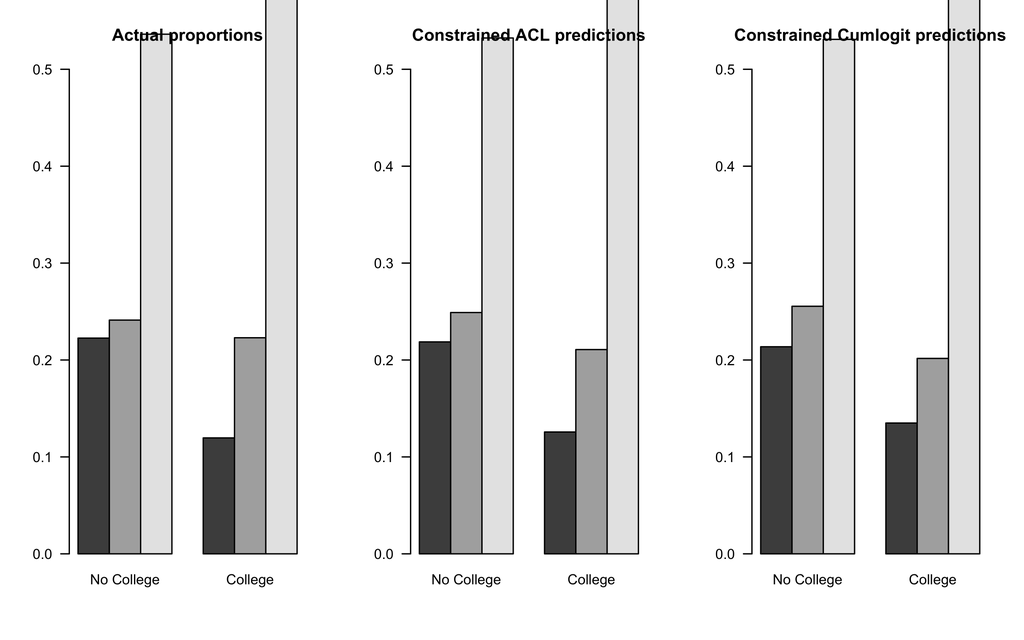

## Fuller models

Sociology 513, Models for Polytomous Categorical Outcomes: Models for Ordinal Outcomes

```
##                            cumlogit cumlogit, c     ACL  ACL, c
## (Intercept):1                0.2287      0.3823 -0.5287 -0.3414
## (Intercept):2               -0.8679     -0.9994  0.0918 -0.0576
## collegeTRUE:1                0.5681      0.4089  0.3900  0.2872
## collegeTRUE:2                0.3611              0.2230
## religMainline Protestant:1   1.7374      1.4359  1.3174  0.9612
## religMainline Protestant:2   1.2851              0.7248
## religCatholic:1              1.9903      1.6374  1.4621  1.1021
## religCatholic:2              1.4827              0.8746
## religJewish:1                2.0663      2.3065  0.6152  1.4896
## religJewish:2                2.2624              1.9440
## religNon-religious:1         3.1510      2.7997  1.7109  1.9907
## religNon-religious:2         2.6913              2.0301
## religOther:1                 1.2760      1.5119  0.4668  0.9380
## religOther:2                 1.4799              1.2417
## I(age - 40):1               -0.0127     -0.0227  0.0081 -0.0145
## I(age - 40):2               -0.0255             -0.0297
## I((age - 40)^2):1            0.0000      0.0002 -0.0003  0.0001
## I((age - 40)^2):2            0.0002              0.0003
```

## Predict the effects of age

Sociology 513, Models for Polytomous Categorical Outcomes: Models for Ordinal Outcomes

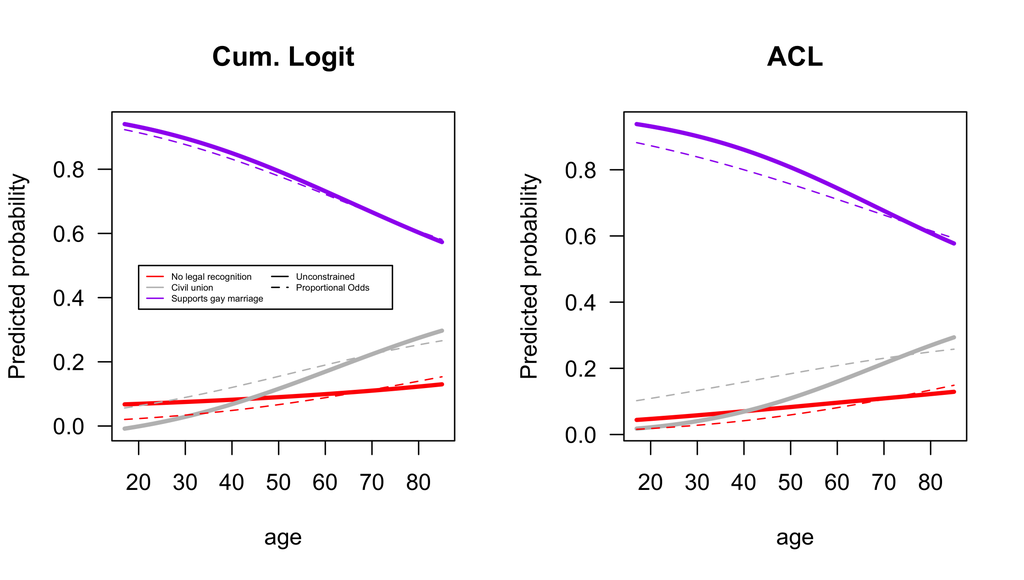